# Exploratory data analysis : COVID19 package

Paul Trincklin, Jiacheng FU, Ruiqi WANG

26/12/2021

Dans ce rapport, nous allons utiliser le package COVID19, qui contient un large dataframe de données mondiales de suivi de divers indicateur de la pandémie, comme les cas, décès, politiques gouvernementales, tests, hospitalisations. L’objectif est d’utiliser ces données combiner à la tidyverse et en particulier le module ggplot pour proposer des visualisation intéressantes ainsi que des propositions d’explications sur ces données.

# Présentation des données

Voici ci-dessous un extrait des données, concernant la France. On peut y voir de nombreux indicateurs correspondant au nom des colonnes, et on va par la suite en détailler quelques-uns.

|  | id | date | confirmed | deaths | recovered | tests | vaccines | people_vaccinated | people_fully_vaccinated | hosp | icu | vent | school_closing | workplace_closing | cancel_events | gatherings_restrictions | transport_closing | stay_home_restrictions | internal_movement_restrictions | international_movement_restrictions | information_campaigns | testing_policy | contact_tracing | facial_coverings | vaccination_policy | elderly_people_protection | government_response_index | stringency_index | containment_health_index | … |
| --- | --- | --- | --- | --- | --- | --- | --- | --- | --- | --- | --- | --- | --- | --- | --- | --- | --- | --- | --- | --- | --- | --- | --- | --- | --- | --- | --- | --- | --- | --- |
| 1 | 5eda1083 | 2020-01-22 |  |  |  |  |  |  |  |  |  |  | 0 | 0 | 0 | 0 | 0 | 0 | 0 | 1 | 0 | 0 | 0 | 1 | 0 | 0 | 3.12 | 2.78 | 3.57 | … |
| 2 | 5eda1083 | 2020-01-23 |  |  |  |  |  |  |  |  |  |  | 0 | 0 | 0 | 0 | 0 | 0 | 0 | 1 | 0 | 0 | 0 | 1 | 0 | 0 | 3.12 | 2.78 | 3.57 | … |
| 3 | 5eda1083 | 2020-01-24 | 2 |  |  |  |  |  |  |  |  |  | 0 | 0 | 0 | 0 | 0 | 0 | 0 | 1 | -1 | 0 | 0 | 1 | 0 | 0 | 4.69 | 5.56 | 5.36 | … |
| 4 | 5eda1083 | 2020-01-25 | 3 |  |  |  |  |  |  |  |  |  | 0 | 0 | 0 | 0 | 0 | 0 | 0 | 1 | -1 | 2 | 1 | 1 | 0 | 0 | 11.98 | 5.56 | 13.69 | … |
| 5 | 5eda1083 | 2020-01-26 | 3 |  |  |  |  |  |  |  |  |  | 0 | 0 | 0 | 0 | 0 | 0 | 0 | 1 | -1 | 2 | 1 | 1 | 0 | 0 | 11.98 | 5.56 | 13.69 | … |
| 6 | 5eda1083 | 2020-01-27 | 3 |  |  |  |  |  |  |  |  |  | 0 | 0 | 0 | 0 | 0 | 0 | 0 | 1 | -1 | 2 | 1 | 1 | 0 | 0 | 11.98 | 5.56 | 13.69 | … |
| 7 | 5eda1083 | 2020-01-28 | 4 |  |  |  |  |  |  |  |  |  | 0 | 0 | 0 | 0 | 0 | 0 | 0 | 1 | -1 | 2 | 1 | 1 | 0 | 0 | 11.98 | 5.56 | 13.69 | … |
| 8 | 5eda1083 | 2020-01-29 | 5 |  |  |  |  |  |  |  |  |  | 0 | 0 | 0 | 0 | 0 | 0 | 0 | 1 | -1 | 2 | 1 | 1 | 0 | 0 | 11.98 | 5.56 | 13.69 | … |
| 9 | 5eda1083 | 2020-01-30 | 5 |  |  |  |  |  |  |  |  |  | 0 | 0 | 0 | 0 | 0 | 0 | 0 | 1 | -1 | 2 | 1 | 1 | 0 | 0 | 11.98 | 5.56 | 13.69 | … |
| 10 | 5eda1083 | 2020-01-31 | 5 |  |  |  |  |  |  |  |  |  | 0 | 0 | 0 | 0 | 0 | 0 | 0 | 1 | -1 | 2 | 1 | 1 | 0 | 0 | 11.98 | 5.56 | 13.69 | … |

[output cut: 1055 more lines]

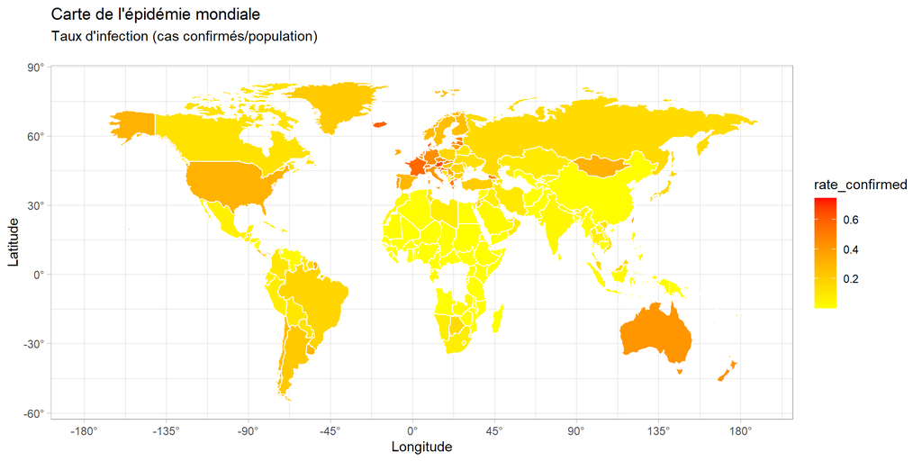

# Cas recensées

Voici les cas rencensés par 3 pays, en fonction du temps:

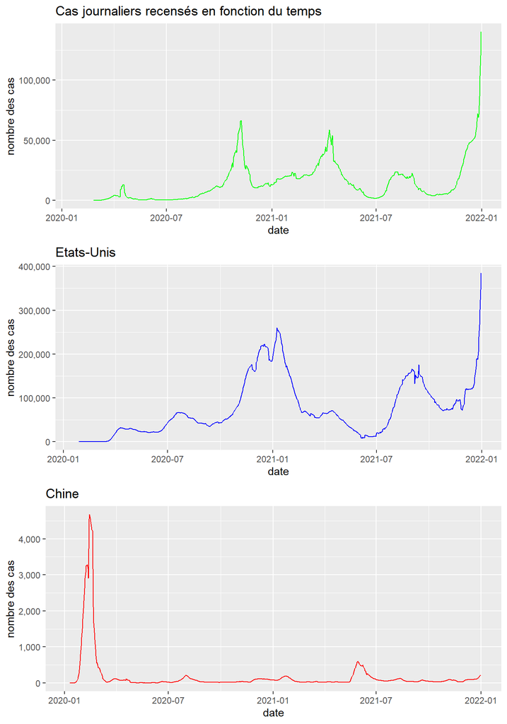

On remarque que les dynamiques sont assez différentes. La Chine, premier pays touché, a subi une vague initiale, mais des mesures très contraignantes ont permis de garder un nombre de cas faible par la suite. D’autres pays, comme la France et les Etats-Unis, ont été touché plus tard. on s’aperçoit que le nombre relevé début 2020 sont très faible, alors que c’est le pic de l’épidémie, ce qui montre une limite du jeu de données: elles correspondent à ce qui est déclaré par les gouvernements, mais ce n’est pas toujours représentatif de la réalité. Ce graphe montre que l’épidémie fonctionne par vagues, liées soit aux conditions climatiques (les pics les plus grands ont lieu l’hiver) soit à l’apparition de nouveaux variants (comme sur les données récentes). Ces données ne sont pas à la même échelle, c’est ce que l’on fait sur le graphe suivant:

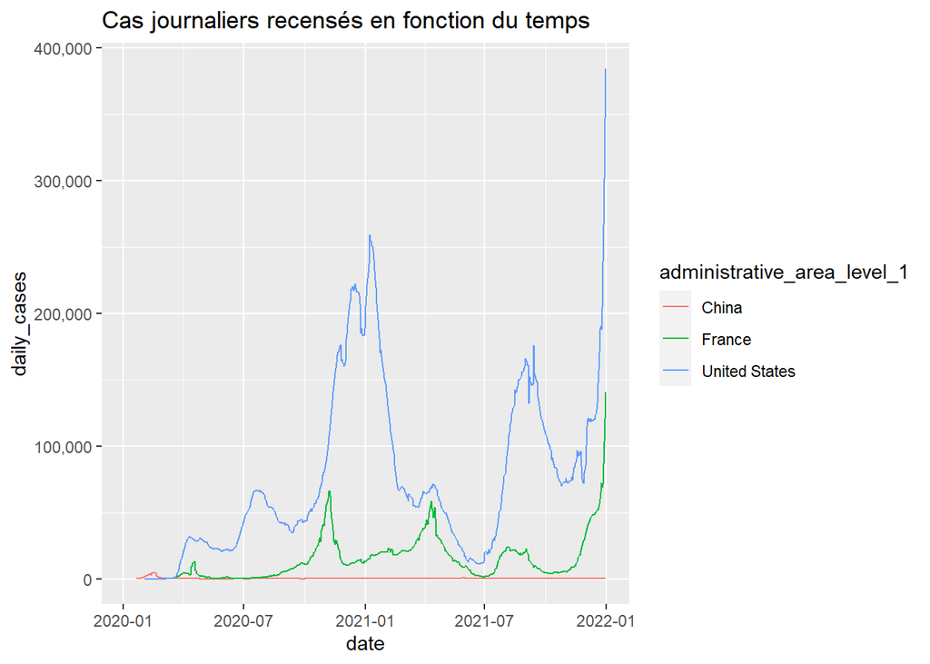

On voit ici la différence entre la Chine et les autres pays. Seules des mesures politiques drastiques peuvent contenir l’épidémie.

On peut regarder sur quelques pays mondiaux la proportion totale des personnes infectées:

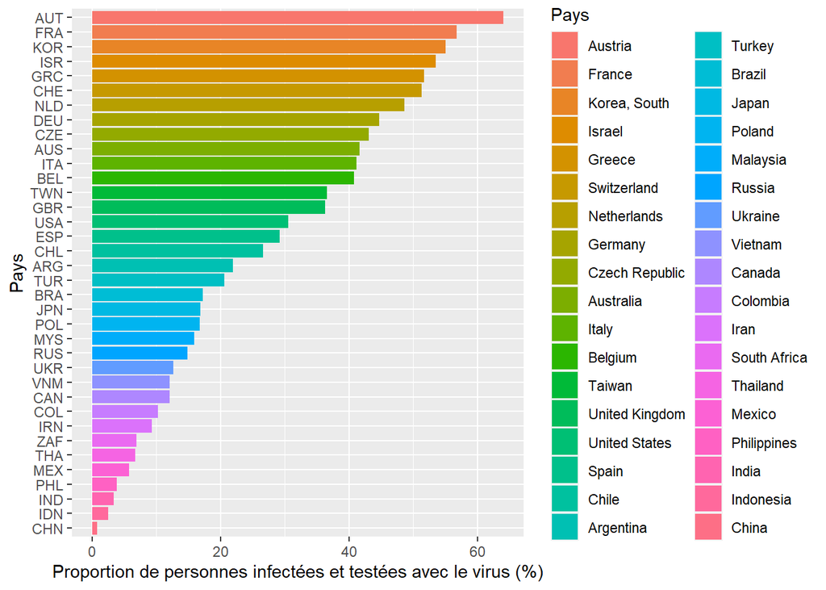

Ce graphe ne permet pas de tirer de conclusion claire: les pays développés semblent avoir subi l’épidémie de manière plus importante, mais cette différence peut s’attribuer à une meilleure remontée des données et une plus grande capacité de tests. On voit une autre limité des données. Les données les mieux partagées sont celles des Etats-Unis (par exemple, les décès français ne sont pas présent sur la première année), c’est pourquoi on se concentrera sur ce pays.

# Décès liées au COVID19

On superpose, en les remettant à l’échelle, les nombres de cas et les décès liées au virus.

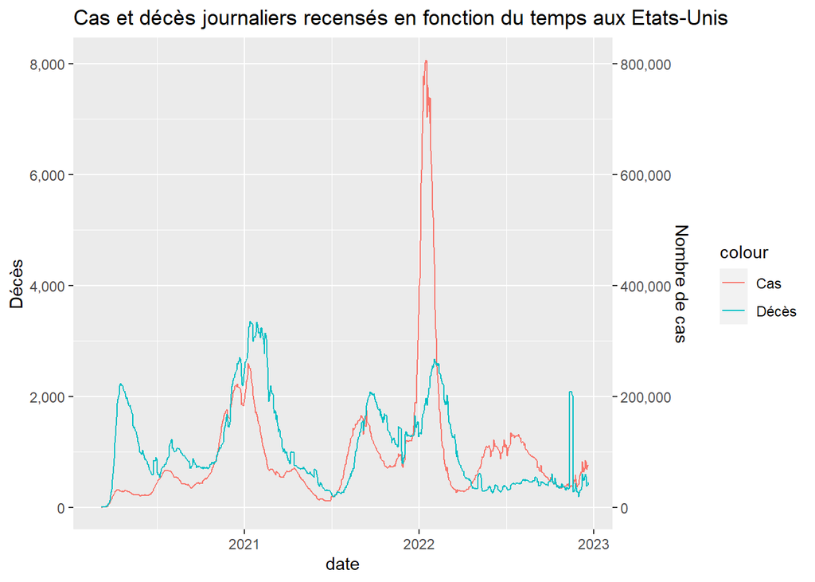

On voit que les deux courbes semblent très corrélées: le nombre de décès suit le nombre de cas, avec un léger décalage. On peut faire une interprétation de ce décalage: les malades sont admis à l’hôpital plusieurs jours après s’être fai tester, ce qui induit un décalage.

On regarde ensuite le taux de mortalité, c’est à dire la proportion de décès par rapport aux cas recensés.

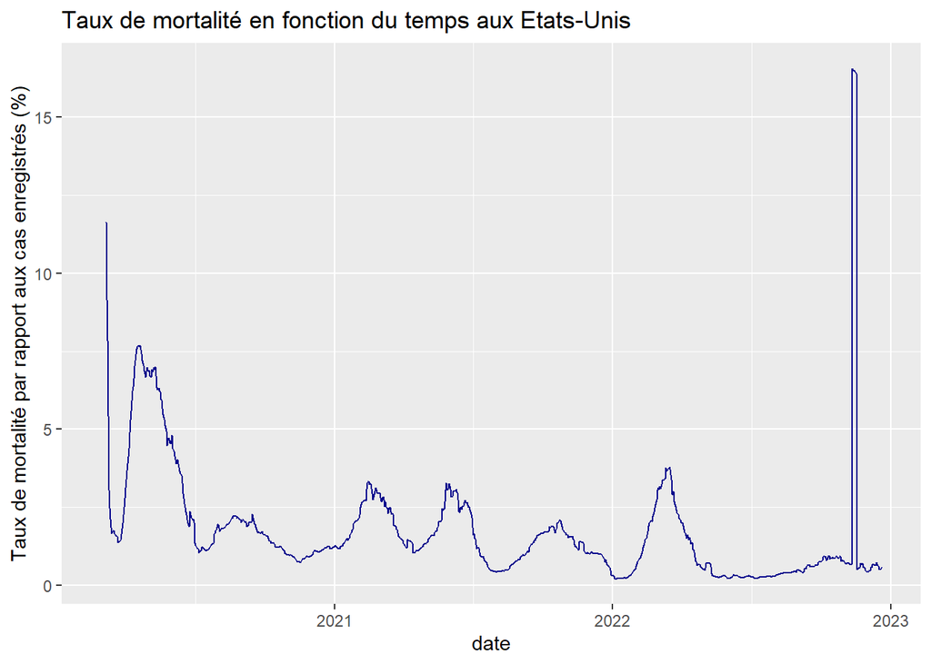

Voici ensuite, dans différents pays, le pourcentage de personnes décédés du COVID19 par pays.

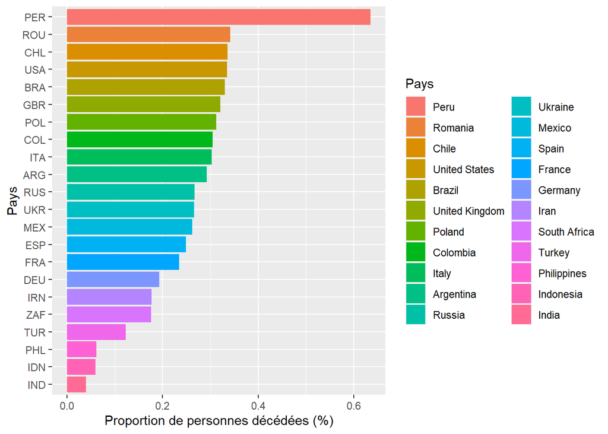

La valeur très élevée au Pérou peut s’expliquer par la forte présence de population indigène disposant d’un faible accès au soin. Le nombre de décès est d’environ 200 pour 100.000 habitants dans les pays européens, et ce taux varie de manière modérée selon les régions.

# Taux de positivité

Voici la variation du taux de positivité aux états-unis:

[figure not shown]

# Vaccination

Heuresement, il existe aussi des moyens pour lutter contre l’épidémie. Le plus important est la vaccination: tous les pays du monde ont développé des politiques massives d’incitation, voici ci-dessous la proportion de personnes vaccinées avec 2 doses par pays.

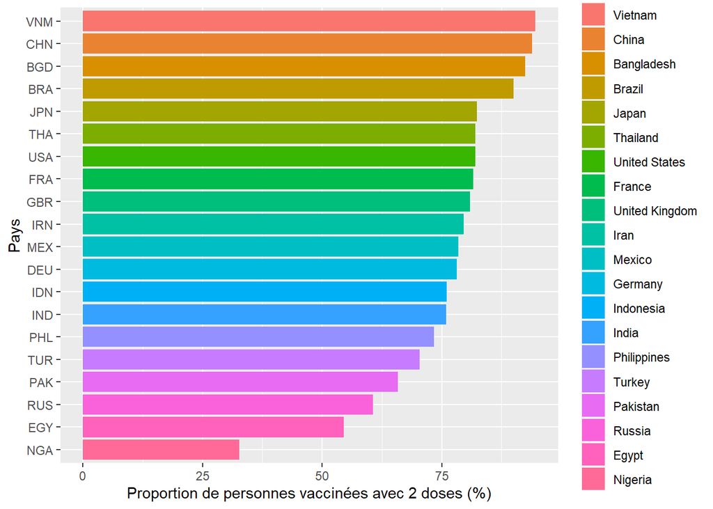

Pour une vaccination complète, il faut au minimum 2 doses. On trace ci-dessous les personnes totalement vaccinées, en rouge, et partiellement vaccinés, en orange.

[figure not shown]

# Politiques gouvernementales

On représente, en plus du nombre de cas recensés, l’indice de support économique en rouge et l’indice de réponse gouvernementale en noir en France.

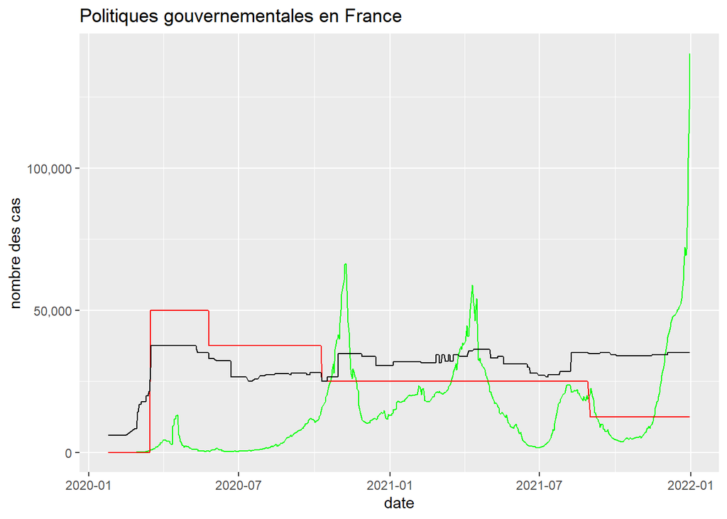

On regarde en France le nombre de jours de fermetures des écoles, correspondant à la catégorie 3 pour une fermeture totale et 2 pour une fermeture partielle. le nombre de jour de fermeture complète a été de 50 jours pendant la première vague.

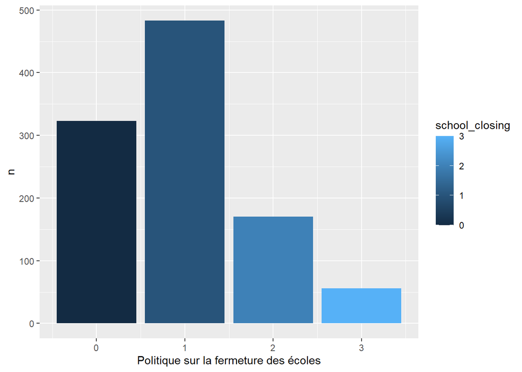

Voici la légende pour la répartition en catégories: 0 - no measures 1 - recommend closing or all schools open with alterations resulting in significant differences compared to non-Covid-19 operations 2 - require closing (only some levels or categories, eg just high school, or just public schools) 3 - require closing all levels

On compare les données de restriction de déplacements internationnaux entre différents pays:

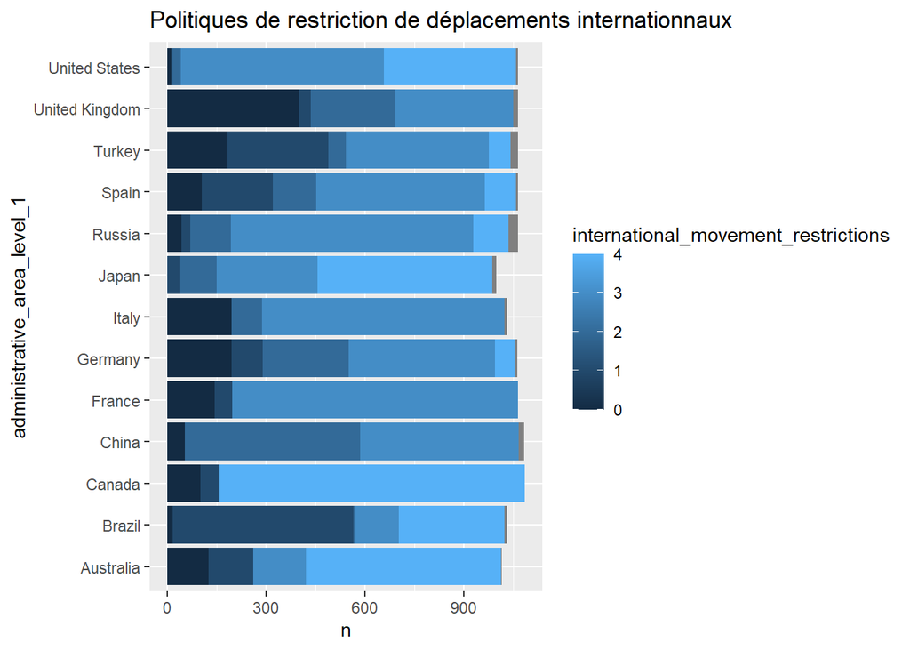

Quelques pays ont des restrictions importantes sur de longues périodes: Australie, Canada et Japon. D’autres ont été plus souples: Brésil, Turquie, et Royaume-Uni. Voici la légende: 0 - no restrictions 1 - screening arrivals 2 - quarantine arrivals from some or all regions 3 - ban arrivals from some regions 4 - ban on all regions or total border closure

# Relation Cas-décès

On analyse la relation entre le nombre de cas confirmés et le décès.

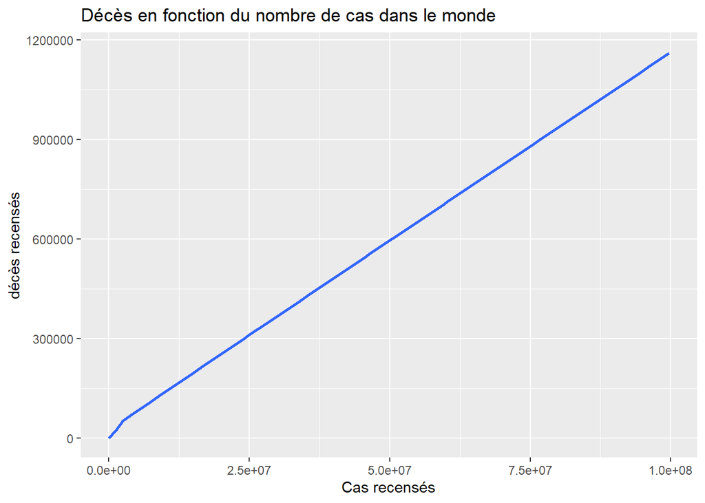

```
##
##  Pearson's product-moment correlation
##
## data:  tem$max_confirmed and tem$max_deaths
## t = 10.822, df = 8, p-value = 4.691e-06
## alternative hypothesis: true correlation is not equal to 0
## 95 percent confidence interval:
##  0.8645013 0.9925204
## sample estimates:
##       cor
## 0.9675032
```

On trouve que p-value est assez petit (<<0.05), il existe une très forte corrélation entre le cas confirmé et le décès.

```
##
## Call:
## lm(formula = max_deaths ~ max_confirmed, data = tem)
##
## Residuals:
##    Min     1Q Median     3Q    Max
## -96320 -18924  -9536  -9456 260674
##
## Coefficients:
##                Estimate Std. Error t value Pr(>|t|)
## (Intercept)   9.380e+03  3.653e+04   0.257    0.804
## max_confirmed 1.173e-02  1.084e-03  10.822 4.69e-06 ***
## ---
## Signif. codes:  0 '***' 0.001 '**' 0.01 '*' 0.05 '.' 0.1 ' ' 1
##
## Residual standard error: 103200 on 8 degrees of freedom
##   (因为不存在，226个观察量被删除了)
## Multiple R-squared:  0.9361, Adjusted R-squared:  0.9281
## F-statistic: 117.1 on 1 and 8 DF,  p-value: 4.691e-06
```

le facteur R^2 très proche de 1 implique aussi une bonne régression

```
##
##  F test to compare two variances
##
## data:  tem$max_confirmed and tem$max_deaths
## F = 6648.9, num df = 14, denom df = 14, p-value < 2.2e-16
## alternative hypothesis: true ratio of variances is not equal to 1
## 95 percent confidence interval:
##   2232.23 19804.30
## sample estimates:
## ratio of variances
##           6648.891
```

# Graphe animé

On peut également avec ggplot créer des graphes animés.Voici pour finir, dans 5 pays, l’évolution du nombre de cas recensés:

[video not shown]